# TCP Congestion Control

Data Network — Transport Layer

Published

April 16, 2026

# 1 개요 (Overview)

TCP Congestion Control은 네트워크의 혼잡(congestion)을 탐지하고 대응함으로써, 송신 측이 네트워크 용량을 초과하지 않는 선에서 최대 처리량을 달성하도록 하는 **엔드-투-엔드(end-to-end) 메커니즘**이다. IP 계층은 혼잡에 대한 명시적 피드백을 제공하지 않기 때문에, TCP는 **패킷 손실(loss event)**을 혼잡의 암묵적(implicit) 신호로 삼아 전송 속도를 스스로 조절한다.

**Flow Control vs. Congestion Control**

| 구분 | Flow Control | Congestion Control |
| --- | --- | --- |
| 목적 | 수신 버퍼 오버플로우 방지 | 네트워크 혼잡 방지 |
| 피드백 | 수신자의 `rwnd` (Receive Window) | 손실 이벤트 (Timeout / 3 Dup ACK) |
| 제어 대상 | Sender ↔︎ Receiver 쌍 | 네트워크 전체 |

## 1.1 왜 “Router”를 특정하는가?

혼잡의 정의에서 항상 “router의 버퍼 오버플로우”, “router 버퍼의 큐잉 지연”이라고 표현한다. Switch에서도 동일한 현상이 발생하는데, 왜 router를 특정하는 것일까?

**① 계층 구조 문제 (주된 이유)**

Switch는 L2(데이터 링크 계층) 장비로 MAC 주소 기반으로 동작하고, Router는 L3(네트워크 계층) 장비로 IP 주소 기반으로 동작한다. TCP는 Transport Layer이고, TCP가 “보고 있는” 경로는 IP 패킷이 지나는 경로, 즉 **router들로 이루어진 경로**다. TCP 입장에서 경로 중간의 장비는 곧 router이다.

Switch에서도 버퍼 오버플로우와 큐잉 지연이 똑같이 발생한다. 하지만 TCP 혼잡 제어의 관심 범위는 “IP 경로에서 발생하는 혼잡”이므로 표현 상 router를 특정하는 것이다.

**② IP layer의 명시적 피드백 부재 (보조적 이유)**

IP는 best-effort 서비스이고, 혼잡 상태를 TCP에게 명시적으로 알려주지 않는다(ECN이 나오기 전까지). 그래서 TCP는 router 내부 상태를 직접 알 수 없고, **패킷 손실 / RTT 증가라는 간접 신호**로만 혼잡을 추론한다. 이것이 “end-end congestion control (no network assistance)”라고 부르는 이유다.

두 이유는 독립적이다. Router를 특정하는 것은 **L3 IP 경로를 다루기 때문**이고, IP가 명시적 피드백을 제공하지 않는 것은 TCP가 **암묵적 신호에 의존할 수밖에 없는 이유**다.

## 1.2 핵심 변수

$$\text{LastByteSent} - \text{LastByteAcked} \leq \min(\underbrace{cwnd}_{\text{congestion window}},\ \underbrace{rwnd}_{\text{flow control window}})$$

- **`cwnd` (Congestion Window)**: 송신자가 네트워크에 주입할 수 있는 unACKed 바이트 수의 상한. 동적으로 변화한다.
- **`ssthresh` (Slow Start Threshold)**: Slow Start와 Congestion Avoidance 사이의 전환 기준값.
- **전송 속도 근사**:

$$\text{rate} \approx \frac{cwnd}{RTT} \quad \text{[bytes/sec]}$$

# 2 cwnd와 전송률 제한의 원리

## 2.1 cwnd란 무엇인가?

`Congwin` = **Congestion Window (`cwnd`)** 다. 슬라이딩 윈도우에서의 “연속적인 윈도우”가 맞지만, 그 크기가 네트워크 혼잡도에 따라 동적으로 조절되는 **혼잡 제어용 윈도우**다.

## 2.2 왜 cwnd가 전송률을 제한하는가?

TCP sender는 다음 불변식(invariant)을 항상 유지한다:

$$\text{LastByteSent} - \text{LastByteAcked} \leq cwnd$$

즉, **네트워크 상에 “날아다니는(in-flight)” 미확인(unACKed) 바이트 수**가 cwnd를 넘을 수 없다. cwnd만큼 보내고 나면 반드시 ACK를 기다려야 다음 데이터를 보낼 수 있다. 이것이 전송률 제한의 본질이다.

$$\text{전송률} \approx \frac{cwnd}{RTT} \text{ [bytes/sec]}$$

## 2.3 cwnd 그림 해석 — 왜 실제 전송 구간보다 cwnd가 더 넓은가?

| 구간 | 색상 | 의미 |
| --- | --- | --- |
| `send_base` 왼쪽 | 초록 | Already ACKed (전송 완료) |
| `send_base` ~ `nextseqnum` | 노랑 | **Sent, not yet ACKed** (전송했지만 ACK 미수신) |
| `nextseqnum` ~ cwnd 끝 | 파랑 | **Usable, not yet sent** (보내도 되지만 아직 안 보냄) |
| cwnd 끝 이후 | 흰색 | Not usable (아직 보낼 수 없음) |

cwnd는 **“보낼 수 있는 권한의 상한(upper bound)”** 이지, 반드시 채워야 하는 의무가 아니다. 파란 구간(usable, not yet sent)이 존재하는 이유는 Application이 아직 데이터를 소켓에 쓰지 않았거나, 전송 파이프라인상 아직 채우기 전인 상태이기 때문이다.

실제로 Application 레이어가 데이터를 충분히 빠르게 공급하면 파란 구간은 거의 없이 cwnd 전체가 채워진다. 파란 구간은 “cwnd가 허용은 하지만 아직 사용되지 않은 여유”를 나타낸다.

# 3 혼잡의 비용 (Costs of Congestion)

TCP 혼잡 제어를 이해하려면 먼저 혼잡 자체가 왜 발생하고, 얼마나 큰 비용을 유발하는지 파악해야 한다.

## 3.1 Scenario 1: 이상적인 상황 (무한 버퍼, 재전송 없음)

**설정:** 두 호스트(A, B)가 용량 $R$의 공유 링크를 통해 데이터를 전송. 라우터 버퍼는 무한, 재전송 없음.

라우터 버퍼가 무한하고 재전송이 없다고 가정하면, 입력 부하($\lambda_{in}$)가 링크 용량 $R/2$에 가까워질수록 지연(delay)이 무한대로 발산한다.

$$\lim_{\lambda_{in} \to R/2} \text{delay} = \infty$$

**왜 delay가 무한대로 발산하는가?**

큐잉 이론으로 생각하면 가장 명확하다. 서비스율을 $\mu$, 도착률을 $\lambda$라 하면:

$$E[\text{delay}] \propto \frac{1}{\mu - \lambda}$$

두 호스트가 용량 $R$의 링크를 공유하므로 각 연결의 최대 처리율은 $R/2$이다. 각 sender의 도착률 $\lambda_{in} \to R/2$이면 총 도착률이 $R$에 수렴하여 링크가 포화된다.

**직관적 비유:** 은행 창구 처리 속도와 거의 동일한 속도로 손님이 오면 줄이 끝없이 길어진다. 버퍼가 무한하면 패킷이 드롭되지 않고 큐에 계속 쌓인다.

| $\lambda_{in}$ | 상태 | delay |
| --- | --- | --- |
| $\ll R/2$ | 큐가 안정적으로 소화됨 | 유한, 작음 |
| $\to R/2$ | 도착 ≈ 처리 (마진 없음) | $\to \infty$ |

**핵심 통찰:** throughput은 $R/2$로 포화되어 좋아 보이지만, delay는 폭발한다. 이것이 “처리량은 좋아 보이지만 실제론 나쁜” 혼잡의 역설이다.

## 3.2 Scenario 2: 유한 버퍼 + 재전송 (현실적 상황)

**설정:** 버퍼가 유한하여 패킷 드롭 발생, 송신자는 손실 시 재전송.

세 가지 현실성 수준으로 전개된다:

**① 이상적 지식(Perfect Knowledge):** sender가 버퍼 여유 공간을 완벽히 알아서 꽉 찼을 때만 전송 → 손실 없음, goodput = offered load.

**② 알려진 손실만 재전송(Known Loss):** 진짜 드롭된 것만 재전송한다고 가정하면 goodput은 여전히 $R/2$에 근접 가능하지만 재전송 트래픽이 overhead를 발생시킨다.

$$\lambda_{out} < \lambda_{in}' \quad (\lambda_{in}' = \text{original} + \text{retransmitted})$$

**③ 현실: 조기 타임아웃(Premature Timeout):** sender가 아직 큐에 있는(손실 안 된) 패킷을 타임아웃으로 재전송 → **같은 패킷의 두 복사본이 링크를 차지** → goodput이 $R/4$까지 떨어진다.

재전송 자체가 네트워크에 추가 부하를 주고, 그 부하가 또 혼잡을 심화시키는 **양의 피드백(positive feedback) 악순환**이 만들어진다.

**혼잡의 비용 (Scenario 2):** 1. 주어진 goodput을 달성하기 위한 **재전송 오버헤드** 증가 2. 불필요한 재전송으로 인한 **goodput 감소** ($\lambda_{out} < \lambda_{in}$)

## 3.3 Scenario 3: 멀티홉 경로 (가장 치명적)

**설정:** 4개 호스트, 각 연결이 2-hop 경로를 경유, 라우터 버퍼 유한.

```
Host A ──→ [R1] ──→ [R2] ──→ Host C
                ↑
Host D ─────────┘──→ Host B
```

A→C 연결이 R1, R2를 거친다. D→B 연결도 R2를 지난다.

- R2 앞에서 A→C 트래픽과 D→B 트래픽이 경쟁
- D→B 트래픽이 증가하면 R2에서 A→C 패킷이 드롭
- **R1은 이미 A→C 패킷을 처리하는 데 자원을 소비했는데, R2에서 드롭되면 그 자원이 완전히 낭비됨**

**Scenario 3의 핵심 비용:**

“upstream에서 소비된 모든 전송 자원이, downstream 드롭 한 번으로 증발한다.”

**세 가지 시나리오 비교 요약:**

|  | Scenario 1 | Scenario 2 | Scenario 3 |
| --- | --- | --- | --- |
| 버퍼 | 무한 | 유한 | 유한 |
| 재전송 | 없음 | 있음 | 있음 |
| 주요 비용 | delay $\to \infty$ | goodput 감소 | 업스트림 자원 낭비 |
| 최대 goodput | $R/2$ (이론) | $< R/2$ (현실) | $\to 0$ (극단) |

# 4 TCP 혼잡 제어 알고리즘

TCP 혼잡 제어는 세 가지 핵심 상태(state)로 구성된다.

## 4.1 Slow Start (SS)

연결 초기에 가용 대역폭을 빠르게 탐색하기 위해 `cwnd`를 **지수적(exponential)**으로 증가시킨다.

**동작 규칙:**

- 초기값: $cwnd = 1 \text{ MSS}$
- **매 ACK 수신 시**: $cwnd \mathrel{+}= 1 \text{ MSS}$
- 결과: 매 RTT마다 `cwnd`가 **2배** 증가

$$cwnd(t + 1 \text{ RTT}) = 2 \cdot cwnd(t)$$

**왜 지수적(exponential)인가?**

핵심은 **“무엇을 단위로 1씩 증가하는가”** 다. RTT당 1씩이 아니라 **ACK 1개당 1씩** 증가한다.

$cwnd = N$ MSS 상태에서 한 RTT에 $N$개의 세그먼트를 전송하면, 돌아오는 ACK도 $N$개다. 각 ACK마다 `cwnd += 1 MSS` 이므로:

$$cwnd_{\text{다음 RTT}} = cwnd + \underbrace{N}_{\text{ACK 수}} \times 1\text{ MSS} = cwnd + cwnd = 2 \times cwnd$$

따라서 RTT마다 **2배씩** 증가한다. $1 \to 2 \to 4 \to 8 \to 16 \to \cdots$ — 이것이 지수적 증가다.

“RTT마다 1씩 증가”한다고 착각하기 쉽지만, **“ACK마다 1씩 증가”** → **“RTT마다 현재 cwnd만큼 증가”** 가 정확한 해석이다.

**종료 조건:**

| 이벤트 | 동작 |
| --- | --- |
| `cwnd >= ssthresh` | Congestion Avoidance로 전환 |
| Timeout (패킷 손실) | `ssthresh = cwnd/2`, `cwnd = 1 MSS`, SS 재시작 |
| 3 Duplicate ACKs | `ssthresh = cwnd/2`, `cwnd = ssthresh + 3`, Fast Recovery 진입 |

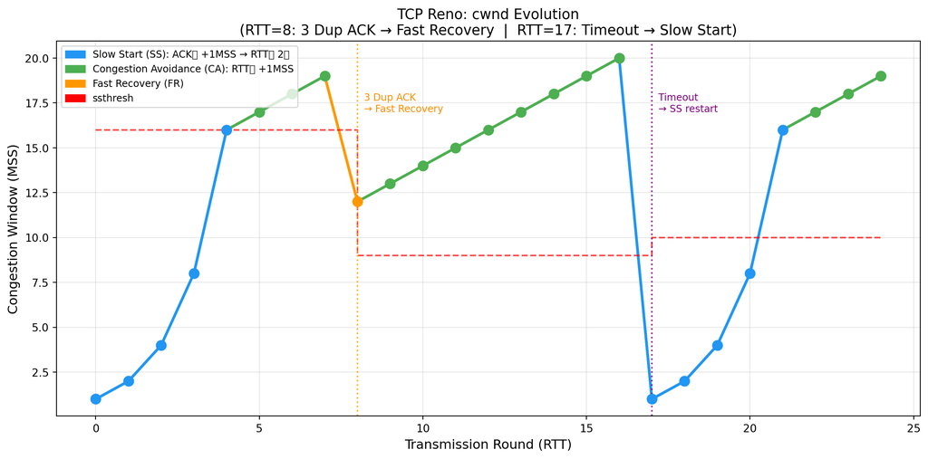

Figure 1: TCP Reno: cwnd 시뮬레이션 (SS→CA→FR→SS 전이 포함)

```python
import matplotlib.pyplot as plt
import matplotlib.patches as mpatches

def simulate_tcp(initial_ssthresh=16, max_rounds=25, loss_at=None):
    cwnd = 1
    ssthresh = initial_ssthresh
    cwnd_history = [cwnd]
    ssthresh_history = [ssthresh]
    states = ['SS']
    for rtt in range(1, max_rounds):
        if loss_at and rtt in loss_at:
            ssthresh = max(cwnd // 2, 1)
            if loss_at[rtt] == 'timeout':
                cwnd = 1
                states.append('SS')
            else:
                cwnd = ssthresh + 3
                states.append('FR')
        else:
            if cwnd < ssthresh:
                cwnd *= 2
                states.append('SS')
            else:
                cwnd += 1
                states.append('CA')
        cwnd_history.append(cwnd)
        ssthresh_history.append(ssthresh)
    return cwnd_history, ssthresh_history, states

cwnd_h, ssthresh_h, states = simulate_tcp(
    initial_ssthresh=16, max_rounds=25,
    loss_at={8: '3dup', 17: 'timeout'}
)

fig, ax = plt.subplots(figsize=(12, 6))
colors = {'SS': '#2196F3', 'CA': '#4CAF50', 'FR': '#FF9800'}
state_colors = [colors.get(s, '#9E9E9E') for s in states]

for i in range(len(cwnd_h)-1):
    ax.plot([i, i+1], [cwnd_h[i], cwnd_h[i+1]],
            color=state_colors[i+1], linewidth=2.5)
    ax.scatter(i, cwnd_h[i], color=state_colors[i], s=80, zorder=5)
ax.scatter(len(cwnd_h)-1, cwnd_h[-1], color=state_colors[-1], s=80, zorder=5)

ax.step(range(len(ssthresh_h)), ssthresh_h, where='post',
        linestyle='--', color='red', alpha=0.7, linewidth=1.5)

ax.axvline(x=8,  color='orange', linestyle=':', alpha=0.8, linewidth=1.5)
ax.axvline(x=17, color='purple', linestyle=':', alpha=0.8, linewidth=1.5)
ax.text(8.2,  max(cwnd_h)*0.85, '3 Dup ACK\n→ Fast Recovery', fontsize=9, color='darkorange')
ax.text(17.2, max(cwnd_h)*0.85, 'Timeout\n→ SS restart',      fontsize=9, color='purple')

ax.set_xlabel('Transmission Round (RTT)', fontsize=12)
ax.set_ylabel('Congestion Window (MSS)', fontsize=12)
ax.set_title('TCP Reno: cwnd Evolution\n(RTT=8: 3 Dup ACK → Fast Recovery  |  RTT=17: Timeout → Slow Start)', fontsize=13)
ax.grid(True, alpha=0.3)

patches = [
    mpatches.Patch(color='#2196F3', label='Slow Start (SS): ACK당 +1MSS → RTT당 2배'),
    mpatches.Patch(color='#4CAF50', label='Congestion Avoidance (CA): RTT당 +1MSS'),
    mpatches.Patch(color='#FF9800', label='Fast Recovery (FR)'),
    mpatches.Patch(color='red',     label='ssthresh'),
]
ax.legend(handles=patches, loc='upper left', fontsize=9)
plt.tight_layout()
plt.show()
```

## 4.2 Congestion Avoidance (CA)

`cwnd >= ssthresh`에 도달하면, 혼잡이 임박했다고 판단하여 `cwnd`를 **선형(linear)**으로 증가시킨다.

**동작 규칙:**

- 매 ACK 수신 시: $cwnd \mathrel{+}= \dfrac{MSS^2}{cwnd}$
- 결과: 매 RTT마다 $cwnd$가 **+1 MSS** 증가 (Additive Increase)
- 손실 이벤트 발생 시: $ssthresh = cwnd/2$, $cwnd \leftarrow cwnd/2$ (Multiplicative Decrease)

**왜 선형(linear)인가? — `MSS²/cwnd`의 의미**

CA의 목표는 RTT당 정확히 +1 MSS 증가다. 이를 달성하는 ACK당 증가량을 역산하면:

$$\underbrace{\frac{cwnd}{MSS}}_{\text{RTT당 ACK 수}} \times x = \text{MSS}
\implies x = \frac{MSS^2}{cwnd}$$

즉 `MSS²/cwnd`는 “RTT당 +1 MSS 선형 증가”를 달성하기 위한 **자동 스케일링 분수**다.

$$\frac{MSS^2}{cwnd} = MSS \times \underbrace{\frac{MSS}{cwnd}}_{\text{전체 cwnd 중 1세그먼트의 비율}}$$

cwnd가 클수록 ACK 한 개의 기여분이 비례해서 작아진다. 예시: MSS = 1,460 bytes, cwnd = 14,600 bytes (10 segments)이면:

$$\frac{1460^2}{14600} = 146 \text{ bytes/ACK}$$

10개의 ACK가 오면 총 $146 \times 10 = 1,460 = \text{MSS}$ → RTT당 정확히 +1 MSS 증가. ✓

**SS와 CA의 비교 정리:**

|  | Slow Start | Congestion Avoidance |
| --- | --- | --- |
| ACK 1개당 증가 | +1 MSS | $+MSS^2/cwnd$ (소량) |
| RTT 1개당 증가 | $+cwnd$ (현재값만큼) | +1 MSS (고정) |
| 그래프 형태 | 지수 곡선 (exponential) | 직선 (linear) |
| 목적 | 대역폭 빠른 탐색 | 혼잡 임박 구간에서 신중한 탐색 |

CA에서 증가량을 의도적으로 작게 만든 이유는, ssthresh를 넘었다는 것 자체가 “이미 이전에 혼잡이 있었던 영역”이기 때문에 신중하게 탐색하기 위함이다.

이것이 바로 **AIMD (Additive Increase, Multiplicative Decrease)** 패러다임이다.

$$\boxed{
\text{AIMD:} \quad
\underbrace{cwnd \mathrel{+}= 1 \text{ MSS per RTT}}_{\text{Additive Increase}}, \quad
\underbrace{cwnd \leftarrow cwnd/2 \text{ on loss}}_{\text{Multiplicative Decrease}}
}$$

**AIMD의 수학적 직관**

두 연결이 동일한 병목 링크를 공유할 때, AIMD는 throughput 공간에서 **45° 등분선(equal share line)**으로 수렴한다.

- **AI 벡터**: $(+1, +1)$ 방향 — 등분선(45°)에 **평행** 이동
- **MD 벡터**: 현재 좌표의 절반 — **원점 방향**으로 이동

이 두 벡터의 조합은 throughput 궤적을 효율적(링크 포화)이고 공정한(등분선 상) 점으로 수렴시킨다.

## 4.3 Fast Retransmit & Fast Recovery (FR)

**Fast Retransmit**: 3개의 Duplicate ACK 수신 시, 타임아웃을 기다리지 않고 즉시 손실 세그먼트를 재전송한다. Dup ACK 자체가 “일부 패킷은 도달하고 있다”는 증거이므로, 네트워크 상태가 timeout보다 양호하다고 판단한다.

**Fast Recovery (TCP Reno)**: Fast Retransmit 이후 Slow Start로 돌아가지 않고, `ssthresh`에서 바로 Congestion Avoidance를 재개한다.

```
# Fast Recovery 진입 조건: 3 Dup ACKs
ssthresh = cwnd / 2
cwnd     = ssthresh + 3   # +3: 이미 수신된 3개의 Dup ACK 보상
→ Fast Recovery 상태 진입
  - 추가 Dup ACK 마다: cwnd += 1 MSS
  - 새 ACK 수신 시:    cwnd = ssthresh  → CA 상태로 전환
  - Timeout 발생 시:   cwnd = 1 MSS    → SS 상태로 전환
```

`+3`의 의미: 3개의 Dup ACK가 도착했다는 것은 “3개의 세그먼트는 수신자 버퍼에 도착했다”는 증거다. 그만큼 in-flight 카운트를 보상해 주는 것이다.

# 5 TCP Tahoe vs. TCP Reno 비교

| 이벤트 | TCP Tahoe | TCP Reno |
| --- | --- | --- |
| **Timeout** | `ssthresh=cwnd/2`, `cwnd=1`, SS 재시작 | 동일 |
| **3 Dup ACK** | `ssthresh=cwnd/2`, **`cwnd=1`**, SS 재시작 | `ssthresh=cwnd/2`, **`cwnd=ssthresh+3`**, Fast Recovery |
| **핵심 철학** | 3 Dup ACK = Timeout과 동일한 심각한 혼잡 | 3 Dup ACK = 덜 심각한 이벤트 (일부 패킷은 도달 중) |

**TCP Reno가 Tahoe보다 효율적인 이유**

3 Dup ACK는 패킷 일부가 여전히 전달되고 있음을 의미한다. cwnd를 1 MSS로 리셋하는 것은 **과도한 반응**이다. Reno는 Fast Recovery를 통해 불필요한 throughput 손실을 방지한다. Reno가 Tahoe보다 throughput이 높은 이유는 **loss 후 회복 속도가 훨씬 빠르기** 때문이다.

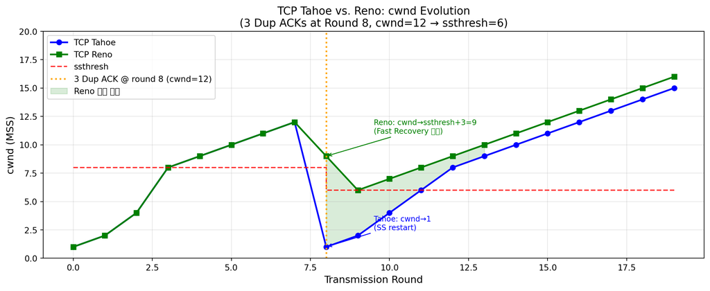

Figure 2: TCP Tahoe vs. Reno: 3 Dup ACK 발생 시 cwnd 비교 (ssthresh=8, loss at cwnd=12)

```python
import matplotlib.pyplot as plt

rounds     = list(range(0, 20))
cwnd_tahoe = [1, 2, 4, 8, 9, 10, 11, 12, 1, 2, 4, 6, 8, 9, 10, 11, 12, 13, 14, 15]
cwnd_reno  = [1, 2, 4, 8, 9, 10, 11, 12, 9, 6, 7, 8,  9, 10, 11, 12, 13, 14, 15, 16]
ssthresh   = [8]*8 + [6]*12

fig, ax = plt.subplots(figsize=(12, 5))
ax.plot(rounds, cwnd_tahoe, 'b-o', markersize=6, linewidth=2, label='TCP Tahoe')
ax.plot(rounds, cwnd_reno,  'g-s', markersize=6, linewidth=2, label='TCP Reno')
ax.step(range(20), ssthresh, 'r--', where='post', linewidth=1.5, alpha=0.8, label='ssthresh')
ax.axvline(x=8, color='orange', linestyle=':', linewidth=2, label='3 Dup ACK @ round 8 (cwnd=12)')

# Reno 이득 구간 강조
ax.fill_between(range(8, 14),
                cwnd_tahoe[8:14], cwnd_reno[8:14],
                alpha=0.15, color='green', label='Reno 이득 구간')

ax.annotate('Tahoe: cwnd→1\n(SS restart)',
            xy=(8, 1), xytext=(9.5, 2.5),
            arrowprops=dict(arrowstyle='->', color='blue'), fontsize=9, color='blue')
ax.annotate('Reno: cwnd→ssthresh+3=9\n(Fast Recovery 진입)',
            xy=(8, 9), xytext=(9.5, 11),
            arrowprops=dict(arrowstyle='->', color='green'), fontsize=9, color='green')

ax.set_xlabel('Transmission Round', fontsize=12)
ax.set_ylabel('cwnd (MSS)', fontsize=12)
ax.set_title('TCP Tahoe vs. Reno: cwnd Evolution\n(3 Dup ACKs at Round 8, cwnd=12 → ssthresh=6)', fontsize=13)
ax.legend(fontsize=10)
ax.grid(True, alpha=0.3)
ax.set_ylim(0, 20)
plt.tight_layout()
plt.show()
```

# 6 TCP 혼잡 제어 FSM

TCP Reno의 전체 상태 전이를 Finite State Machine으로 정리한다.

```
stateDiagram-v2
    [*] --> SlowStart : cwnd=1MSS, ssthresh=64KB

    SlowStart --> SlowStart : New ACK\ncwnd += MSS
    SlowStart --> CongestionAvoidance : cwnd >= ssthresh
    SlowStart --> SlowStart : Timeout\nssthresh=cwnd/2, cwnd=1
    SlowStart --> FastRecovery : 3 Dup ACKs\nssthresh=cwnd/2\ncwnd=ssthresh+3

    CongestionAvoidance --> CongestionAvoidance : New ACK\ncwnd += MSS²/cwnd
    CongestionAvoidance --> SlowStart : Timeout\nssthresh=cwnd/2, cwnd=1
    CongestionAvoidance --> FastRecovery : 3 Dup ACKs\nssthresh=cwnd/2\ncwnd=ssthresh+3

    FastRecovery --> FastRecovery : Dup ACK\ncwnd += MSS
    FastRecovery --> CongestionAvoidance : New ACK\ncwnd=ssthresh
    FastRecovery --> SlowStart : Timeout\nssthresh=cwnd/2, cwnd=1
```

[output not shown]

# 7 TCP Throughput 분석

## 7.1 평균 처리량 (AIMD 모델)

AIMD 거동에서 `cwnd`는 $W/2$에서 $W$ 사이를 반복적으로 진동한다. 손실이 `cwnd = W`일 때 발생한다고 가정하면:

$$\overline{\text{throughput}} = \frac{3}{4} \cdot \frac{W}{RTT} \quad \text{[bytes/sec]}$$

**유도:** 평균 윈도우 크기 $= \dfrac{W/2 + W}{2} = \dfrac{3W}{4}$

## 7.2 Mathis Formula (손실률 기반)

손실 이벤트 발생 확률을 $L$이라 하면 [Mathis 1997]:

$$\overline{\text{throughput}} = \frac{1.22 \cdot MSS}{RTT \cdot \sqrt{L}}$$

**수학적 유도 (직관)**

한 번의 AIMD 사이클에서:

- Additive Increase: $W/2$에서 $W$까지 증가하는 데 $W/2$ RTT 소요
- 해당 기간 전송 총 바이트: $\displaystyle\sum_{k=W/2}^{W} k \cdot MSS \approx \dfrac{3W^2}{8} \cdot MSS$
- 손실 이벤트는 1회 → $L = \dfrac{8}{3W^2}$
- $W = \sqrt{\dfrac{8}{3L}}$ 을 throughput 식에 대입하면 $\dfrac{1.22 \cdot MSS}{RTT\sqrt{L}}$ 도출

## 7.3 Long Fat Pipe 문제

고속 장거리 링크(예: 10 Gbps, RTT=100ms)에서:

$$L \leq 2 \times 10^{-10}$$

이는 사실상 달성 불가능한 낮은 손실률을 요구한다. 이것이 CUBIC, BBR 등 차세대 TCP가 필요한 근본적 이유다.

[figure not shown]

Figure 3: Mathis Formula: 손실률에 따른 TCP Throughput (MSS=1500B, RTT=100ms)

```python
import numpy as np
import matplotlib.pyplot as plt

MSS = 1500
RTT = 0.1
L_range = np.logspace(-10, -2, 500)
throughput_Mbps = (1.22 * MSS) / (RTT * np.sqrt(L_range)) / 1e6

fig, ax = plt.subplots(figsize=(10, 5))
ax.loglog(L_range, throughput_Mbps, 'b-', linewidth=2.5, label='Mathis Formula')

thresholds = {
    10000: ('10 Gbps', 'red'),
    1000:  ('1 Gbps',  'orange'),
    100:   ('100 Mbps','green'),
    10:    ('10 Mbps', 'steelblue'),
}
for tp, (label, color) in thresholds.items():
    L_needed = (1.22 * MSS / (RTT * tp * 1e6))**2
    ax.axhline(y=tp, color=color, linestyle='--', alpha=0.5, linewidth=1)
    ax.axvline(x=L_needed, color=color, linestyle=':', alpha=0.5, linewidth=1)
    ax.text(L_needed * 1.5, tp * 1.4,
            f'{label}\nL={L_needed:.1e}', fontsize=8, color=color)

ax.set_xlabel('Packet Loss Rate (L)', fontsize=12)
ax.set_ylabel('Throughput (Mbps)', fontsize=12)
ax.set_title('TCP Throughput vs. Loss Rate\n(Mathis Formula, MSS=1500B, RTT=100ms)', fontsize=13)
ax.grid(True, which='both', alpha=0.3)
ax.legend()
plt.tight_layout()
plt.show()
```

# 8 TCP 공정성 (Fairness)

## 8.1 AIMD의 공정성 수렴

$K$개의 TCP 연결이 용량 $R$의 병목 링크를 공유할 때, 이상적 공정성 조건:

$$\text{각 연결의 평균 전송률} = \frac{R}{K}$$

두 연결의 경우를 기하학적으로 분석하면:

- **AI 벡터**: $(+1, +1)$ 방향 — 등분선(45°)에 **평행** 이동
- **MD 벡터**: $(0.5 \cdot x_1, 0.5 \cdot x_2)$ — **원점 방향** 이동

이 두 벡터의 조합은 throughput 궤적을 효율적(링크 포화)이고 공정한(등분선 상) 점으로 수렴시킨다.

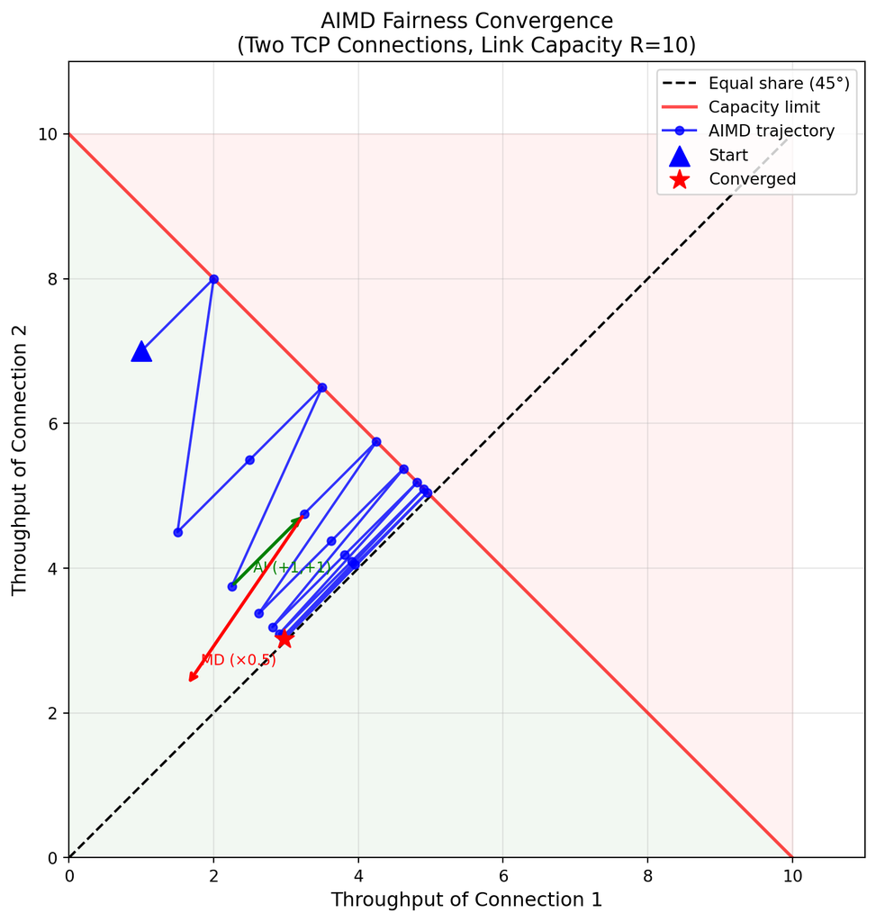

Figure 4: AIMD Fairness: 두 TCP 연결의 Throughput 수렴 궤적

```python
import numpy as np
import matplotlib.pyplot as plt

R = 10
fig, ax = plt.subplots(figsize=(8, 8))

ax.fill_between([0, R], [R, 0], [R, R], alpha=0.05, color='red')
ax.fill_between([0, R], [0, 0], [R, 0], alpha=0.05, color='green')
ax.plot([0, R], [0, R], 'k--', linewidth=1.5, label='Equal share (45°)')
ax.plot([0, R], [R, 0], 'r-',  linewidth=2,   alpha=0.7, label='Capacity limit')

np.random.seed(42)
x1, x2 = 1.0, 7.0
trajectory = [(x1, x2)]
for _ in range(20):
    x1 += 1; x2 += 1
    if x1 + x2 > R:
        x1 *= 0.5; x2 *= 0.5
    trajectory.append((x1, x2))

xs, ys = zip(*trajectory)
ax.plot(xs, ys, 'b-o', markersize=5, linewidth=1.5, alpha=0.8, label='AIMD trajectory')
ax.scatter(xs[0], ys[0], s=150, c='blue', marker='^', zorder=6, label='Start')
ax.scatter(xs[-1], ys[-1], s=150, c='red',  marker='*', zorder=6, label='Converged')

mid_idx = 5
ax.annotate('', xy=(xs[mid_idx]+1, ys[mid_idx]+1),
            xytext=(xs[mid_idx], ys[mid_idx]),
            arrowprops=dict(arrowstyle='->', color='green', lw=2))
ax.text(xs[mid_idx]+0.3, ys[mid_idx]+0.2, 'AI (+1,+1)', fontsize=9, color='green')

ax.annotate('', xy=(xs[mid_idx+1]*0.5, ys[mid_idx+1]*0.5),
            xytext=(xs[mid_idx+1], ys[mid_idx+1]),
            arrowprops=dict(arrowstyle='->', color='red', lw=2))
ax.text(xs[mid_idx+1]*0.5+0.2, ys[mid_idx+1]*0.5+0.3, 'MD (×0.5)', fontsize=9, color='red')

ax.set_xlim(0, R+1); ax.set_ylim(0, R+1)
ax.set_xlabel('Throughput of Connection 1', fontsize=12)
ax.set_ylabel('Throughput of Connection 2', fontsize=12)
ax.set_title('AIMD Fairness Convergence\n(Two TCP Connections, Link Capacity R=10)', fontsize=13)
ax.legend(fontsize=10, loc='upper right')
ax.grid(True, alpha=0.3)
ax.set_aspect('equal')
plt.tight_layout()
plt.show()
```

## 8.2 공정성의 한계

- **RTT 불평등**: RTT가 짧은 연결이 손실 후 더 빨리 `cwnd`를 복구 → 짧은 RTT 연결이 더 높은 throughput 획득
- **병렬 TCP 연결**: 앱이 $N$개 연결을 열면 단일 연결 대비 $N$배 더 많은 대역폭 소비
- **UDP의 무임승차**: UDP는 혼잡 제어가 없어 TCP 연결을 밀어낼 수 있음

# 9 Explicit Congestion Notification (ECN)

기존 TCP는 **손실(loss)**로만 혼잡을 감지하지만, ECN은 **라우터가 명시적으로** 혼잡 신호를 전달하는 네트워크 보조(network-assisted) 방식이다.

## 9.1 동작 메커니즘

```
[송신자] ──────────────────────────────→ [수신자]
          IP datagram: ECN=10 (capable)
                    ↓ (라우터가 혼잡 감지)
          IP datagram: ECN=11 (CE: Congestion Experienced)
[송신자] ←────────────────────────────── [수신자]
          TCP ACK: ECE=1 (Echo CE 비트)
[송신자]: cwnd 절반으로 감소, CWR=1 설정
```

| ECN 비트값 | 의미 |
| --- | --- |
| `00` | ECN 미지원 |
| `10` or `01` | ECN 지원 (ECT: ECN-Capable Transport) |
| `11` | 혼잡 경험 (CE: Congestion Experienced) |

**ECN의 장점**: 패킷이 드롭되기 **전에** 혼잡 신호를 전달하므로, 손실 없이 전송률을 줄일 수 있다. 특히 데이터센터 네트워크(DCTCP)처럼 낮은 지연이 중요한 환경에서 효과적이다.

# 10 시험 대비 핵심 정리

## 10.1 주요 공식 요약

| 항목 | 공식 |
| --- | --- |
| 전송 속도 | $\text{rate} \approx cwnd / RTT$ |
| 평균 throughput | $\overline{T} = \dfrac{3}{4} \cdot \dfrac{W}{RTT}$ |
| Mathis throughput | $\overline{T} = \dfrac{1.22 \cdot MSS}{RTT \cdot \sqrt{L}}$ |
| CA ACK당 증가량 | $\Delta cwnd = MSS^2 / cwnd$ |
| 공정성 조건 | 각 연결 = $R/K$ |

## 10.2 상태별 cwnd 업데이트 규칙

| 상태 | 이벤트 | cwnd 변화 | 비고 |
| --- | --- | --- | --- |
| Slow Start | New ACK | `cwnd += 1 MSS` | ACK당 → RTT당 2배 |
| Slow Start | Timeout | `ssthresh=cwnd/2`, `cwnd=1` |  |
| Slow Start | 3 Dup ACK | `ssthresh=cwnd/2`, `cwnd=ssthresh+3` → FR | Reno만 해당 |
| Congestion Avoidance | New ACK | `cwnd += MSS²/cwnd` | RTT당 +1 MSS |
| Congestion Avoidance | Timeout | `ssthresh=cwnd/2`, `cwnd=1` |  |
| Congestion Avoidance | 3 Dup ACK | `ssthresh=cwnd/2`, `cwnd=ssthresh+3` → FR |  |
| Fast Recovery | Dup ACK | `cwnd += 1 MSS` |  |
| Fast Recovery | New ACK | `cwnd=ssthresh` → CA |  |
| Fast Recovery | Timeout | `ssthresh=cwnd/2`, `cwnd=1` → SS |  |

## 10.3 예제 문제 풀이

**문제:** `ssthresh = 8 MSS`, 초기 `cwnd = 1 MSS`에서 시작하는 TCP Reno 연결이 있다.  
어느 시점에서 3 Dup ACK가 발생하며, 이 시점의 `cwnd = 12 MSS`다.

1. 새로운 `ssthresh`는?
2. Fast Recovery 진입 시 `cwnd`는?
3. 새 ACK 수신 후 `cwnd`와 전환 상태는?

**cwnd 추적 과정 (손실 시점까지):**

| Round | 상태 | cwnd | 근거 |
| --- | --- | --- | --- |
| 1 | SS | 1 | 초기값 |
| 2 | SS | 2 | ACK당 +1 → RTT당 2배 |
| 3 | SS | 4 |  |
| 4 | SS→CA | 8 = ssthresh → CA 전환 | cwnd ≥ ssthresh |
| 5 | CA | 9 | RTT당 +1 |
| 6 | CA | 10 |  |
| 7 | CA | 11 |  |
| 8 | CA | **12** | **→ 3 Dup ACK 발생** |

**풀이:**

**Q1.** 새로운 ssthresh:

$$ssthresh = \frac{cwnd}{2} = \frac{12}{2} = \boxed{6 \text{ MSS}}$$

**Q2.** Fast Recovery 진입 시 cwnd (TCP Reno):

$$cwnd = ssthresh + 3 = 6 + 3 = \boxed{9 \text{ MSS}}$$

**Q3.** Missing segment에 대한 새 ACK 수신 후:

$$cwnd = ssthresh = \boxed{6 \text{ MSS}}, \quad \text{→ Congestion Avoidance 전환}$$

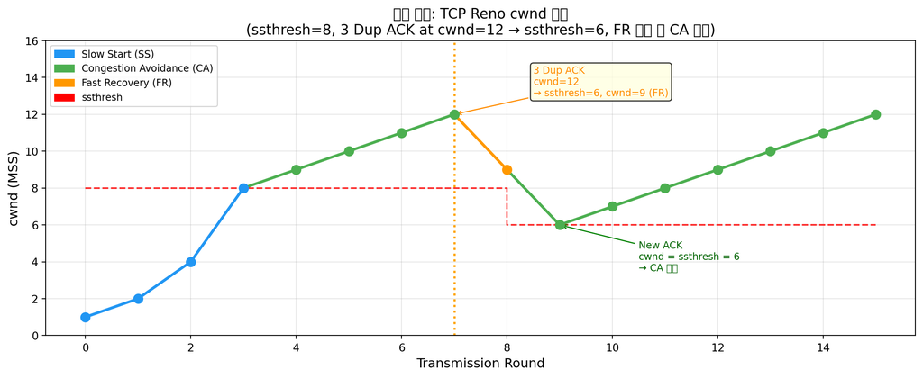

Figure 5: 예제 문제 시각화: ssthresh=8, 3 Dup ACK at cwnd=12

```python
import matplotlib.pyplot as plt
import matplotlib.patches as mpatches

rounds = list(range(0, 16))
cwnd   = [1, 2, 4, 8, 9, 10, 11, 12, 9, 6, 7, 8, 9, 10, 11, 12]
sst    = [8]*8 + [6]*8
states = ['SS','SS','SS','SS','CA','CA','CA','CA','FR','CA','CA','CA','CA','CA','CA','CA']

colors = {'SS':'#2196F3', 'CA':'#4CAF50', 'FR':'#FF9800'}
fig, ax = plt.subplots(figsize=(12, 5))

for i in range(len(cwnd)-1):
    ax.plot([rounds[i], rounds[i+1]], [cwnd[i], cwnd[i+1]],
            color=colors[states[i+1]], linewidth=2.5)
    ax.scatter(rounds[i], cwnd[i], color=colors[states[i]], s=70, zorder=5)
ax.scatter(rounds[-1], cwnd[-1], color=colors[states[-1]], s=70, zorder=5)

ax.step(rounds, sst, 'r--', where='post', linewidth=1.5, alpha=0.8)

ax.axvline(x=7, color='orange', linestyle=':', linewidth=2)
ax.annotate('3 Dup ACK\ncwnd=12\n→ ssthresh=6, cwnd=9 (FR)',
            xy=(7, 12), xytext=(8.5, 13),
            arrowprops=dict(arrowstyle='->', color='darkorange'),
            fontsize=9, color='darkorange',
            bbox=dict(boxstyle='round,pad=0.3', facecolor='lightyellow', alpha=0.8))

ax.annotate('New ACK\ncwnd = ssthresh = 6\n→ CA 재개',
            xy=(9, 6), xytext=(10.5, 3.5),
            arrowprops=dict(arrowstyle='->', color='green'),
            fontsize=9, color='darkgreen')

ax.set_xlabel('Transmission Round', fontsize=12)
ax.set_ylabel('cwnd (MSS)', fontsize=12)
ax.set_title('예제 문제: TCP Reno cwnd 추적\n(ssthresh=8, 3 Dup ACK at cwnd=12 → ssthresh=6, FR 진입 후 CA 재개)', fontsize=13)
ax.grid(True, alpha=0.3)
ax.set_ylim(0, 16)

patches = [
    mpatches.Patch(color='#2196F3', label='Slow Start (SS)'),
    mpatches.Patch(color='#4CAF50', label='Congestion Avoidance (CA)'),
    mpatches.Patch(color='#FF9800', label='Fast Recovery (FR)'),
    mpatches.Patch(color='red',     label='ssthresh'),
]
ax.legend(handles=patches, loc='upper left', fontsize=9)
plt.tight_layout()
plt.show()
```

# 11 참고 문헌

- Kurose, J. F. & Ross, K. W. (2016). *Computer Networking: A Top-Down Approach*, 7th Edition. Pearson.
  - Chapter 3.6: Principles of Congestion Control
  - Chapter 3.7: TCP Congestion Control
- Jacobson, V. (1988). Congestion Avoidance and Control. *ACM SIGCOMM*.
- Mathis, M. et al. (1997). The Macroscopic Behavior of the TCP Congestion Avoidance Algorithm. *ACM SIGCOMM Computer Communication Review*.
- RFC 5681 — TCP Congestion Control.
- RFC 3168 — The Addition of Explicit Congestion Notification (ECN) to IP.